# P8105_hw1_xs2569

Xun Sun

2024-09-12

# 1] problem 1

a short description of the penguins dataset

### 1.1 the data in this dataset

including names / values of important variables

```r
library(ggplot2)
data("penguins", package = "palmerpenguins")
penguins
```

```
## # A tibble: 344 × 8
##    species island    bill_length_mm bill_depth_mm flipper_length_mm body_mass_g
##    <fct>   <fct>              <dbl>         <dbl>             <int>       <int>
##  1 Adelie  Torgersen           39.1          18.7               181        3750
##  2 Adelie  Torgersen           39.5          17.4               186        3800
##  3 Adelie  Torgersen           40.3          18                 195        3250
##  4 Adelie  Torgersen           NA            NA                  NA          NA
##  5 Adelie  Torgersen           36.7          19.3               193        3450
##  6 Adelie  Torgersen           39.3          20.6               190        3650
##  7 Adelie  Torgersen           38.9          17.8               181        3625
##  8 Adelie  Torgersen           39.2          19.6               195        4675
##  9 Adelie  Torgersen           34.1          18.1               193        3475
## 10 Adelie  Torgersen           42            20.2               190        4250
## # ℹ 334 more rows
## # ℹ 2 more variables: sex <fct>, year <int>
```

```r
summary(penguins)
```

```
##       species          island    bill_length_mm  bill_depth_mm
##  Adelie   :152   Biscoe   :168   Min.   :32.10   Min.   :13.10
##  Chinstrap: 68   Dream    :124   1st Qu.:39.23   1st Qu.:15.60
##  Gentoo   :124   Torgersen: 52   Median :44.45   Median :17.30
##                                  Mean   :43.92   Mean   :17.15
##                                  3rd Qu.:48.50   3rd Qu.:18.70
##                                  Max.   :59.60   Max.   :21.50
##                                  NA's   :2       NA's   :2
##  flipper_length_mm  body_mass_g       sex           year
##  Min.   :172.0     Min.   :2700   female:165   Min.   :2007
##  1st Qu.:190.0     1st Qu.:3550   male  :168   1st Qu.:2007
##  Median :197.0     Median :4050   NA's  : 11   Median :2008
##  Mean   :200.9     Mean   :4202                Mean   :2008
##  3rd Qu.:213.0     3rd Qu.:4750                3rd Qu.:2009
##  Max.   :231.0     Max.   :6300                Max.   :2009
##  NA's   :2         NA's   :2
```

```r
View(penguins)
names(penguins)
```

```
## [1] "species"           "island"            "bill_length_mm"
## [4] "bill_depth_mm"     "flipper_length_mm" "body_mass_g"
## [7] "sex"               "year"
```

```r
head(penguins)
```

```
## # A tibble: 6 × 8
##   species island    bill_length_mm bill_depth_mm flipper_length_mm body_mass_g
##   <fct>   <fct>              <dbl>         <dbl>             <int>       <int>
## 1 Adelie  Torgersen           39.1          18.7               181        3750
## 2 Adelie  Torgersen           39.5          17.4               186        3800
## 3 Adelie  Torgersen           40.3          18                 195        3250
## 4 Adelie  Torgersen           NA            NA                  NA          NA
## 5 Adelie  Torgersen           36.7          19.3               193        3450
## 6 Adelie  Torgersen           39.3          20.6               190        3650
## # ℹ 2 more variables: sex <fct>, year <int>
```

There are 8 variables, named species, island, bill_length_mm, bill_depth_mm, flopper_length_mm, body_mass, sex, year.

### 1.2 the size of the dataset

```r
nrow_dataset <- nrow(penguins) # Get the number of columns in the dataset
ncol_dataset <- ncol(penguins) # Print the size of the dataset

cat("The dataset has", nrow_dataset, "rows and", ncol_dataset, "columns.\n")
```

```
## The dataset has 344 rows and 8 columns.
```

### 1.3 the mean flipper length

```r
mean_flipper_length <- mean(penguins$flipper_length_mm, na.rm = TRUE)
cat("The mean flipper length is", mean_flipper_length, "\n")
```

```
## The mean flipper length is 200.9152
```

### 1.4 a scatterplot

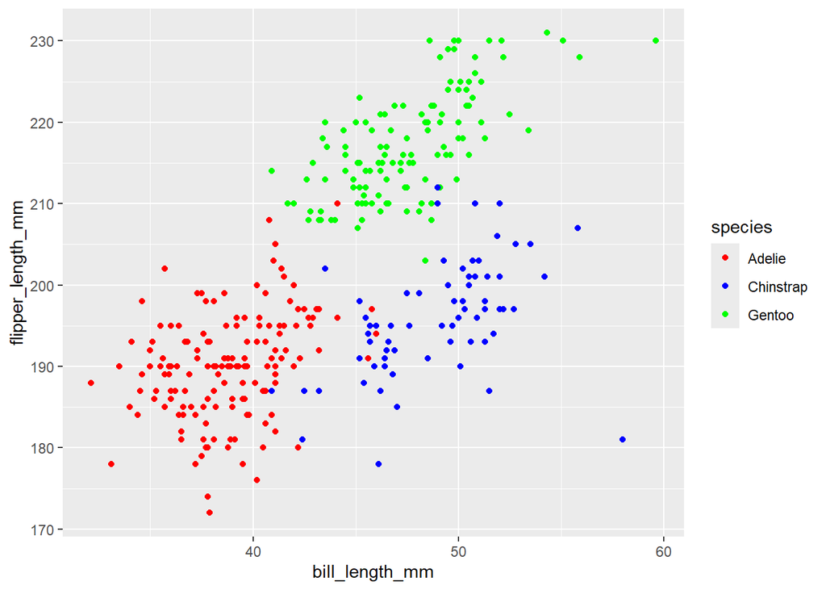

```r
plot1 <- ggplot(penguins, aes(bill_length_mm, flipper_length_mm,color = species)) + geom_point() + scale_color_manual(values = c("Adelie" = "red", "Chinstrap" = "blue", "Gentoo" = "green"))

plot1
```

```r
ggsave("penguin_scatterplot.png", plot = plot1, width = 8, height = 6, units = "in")
```

The scatterplot reveals that although there is some overlap in the data among the three penguin species, each has distinct characteristics regarding bill length and flipper length. Specifically, the Gentoo species generally exhibits higher flipper lengths compared to the other two species. Meanwhile, the Chinstrap and Adelie species show similar flipper lengths, but the Chinstrap species tends to have a larger bill length than the Adelie

# 2] Problem 2

### 2.1 Create a data frame + take the mean

```r
library(tidyverse)
set.seed(1234)
sd <- tibble(
  normal_dist = rnorm(10),
  is_greaterthan0 = normal_dist > 0,
  char_vec = ("DANCINGCAT"),
  char_vec2 = ("1234567890"),
  factor_vec = factor(sample(c("Level1", "Level2", "Level3"), 10, replace = TRUE
)),
  factor_vec2 = factor(sample(c("1", "2", "3"), 10, replace = TRUE
)))

mean_normal_dist <- mean(pull(sd, normal_dist))
mean_is_greaterthan0 <- mean(pull(sd, is_greaterthan0))
### mean_char_vec <- mean(pull(sd, char_vec))
# This will give an error
### mean_char_vec2 <- mean(pull(sd, char_vec2))
# This will give an error
### mean_factor_vec <- mean(pull(sd, mean_factor_vec))
# This will give an error
### mean_factor_vec2 <- mean(pull(sd, mean_factor_vec2))
# This will give an error

print(mean_normal_dist)
```

```
## [1] -0.3831574
```

```r
print(mean_is_greaterthan0)
```

```
## [1] 0.4
```

###### random_sample: This works because random_sample is numeric

###### logical_vector: This works because TRUE/FALSE can be coerced to 1/0

###### character_vector: This won’t work because it’s a character variable (both numbers and strings)

###### factor_vector: This won’t work because it’s a factor

### 2.2 convert variables + explain why

```r
as_numeric_logical <- as.numeric(pull(sd, is_greaterthan0))
as_numeric_char <- as.numeric(pull(sd, char_vec))
as_numeric_char2 <- as.numeric(pull(sd, char_vec2))
as_numeric_factor <- as.numeric(as.character(pull(sd, factor_vec)))
as_numeric_factor2 <- as.numeric(as.character(pull(sd, factor_vec2)))

mean_as_numeric_logical <- mean(as_numeric_logical)
mean_as_numeric_char <- mean(as_numeric_char, na.rm = TRUE) # NA values are ignored
mean_as_numeric_char2 <- mean(as_numeric_char2, na.rm = TRUE) # NA values are ignored
mean_as_numeric_factor <- mean(as_numeric_factor, na.rm = TRUE) # NA values are ignored
mean_as_numeric_factor2 <- mean(as_numeric_factor2, na.rm = TRUE)

print(mean_as_numeric_logical)
print(mean_as_numeric_char)
print(mean_as_numeric_char2)
print(mean_as_numeric_factor)
print(mean_as_numeric_factor2)
```

[output not shown]

#### What Happens:

###### logical to Numeric: The logical values (`TRUE`, `FALSE`) are coerced to 1 and 0.

###### character to Numeric: Characters containing letters or strings cannot be directly converted to numeric values, so `as.numeric()` on character variables will result in `NA` values, but characters containing numbers can be converted to numeric numbers.

###### factor to Numeric: Factors have underlying integer representations (their levels). When you coerce a factor to numeric, R converts each level to its corresponding integer code.

##### Does This Help Explain the `mean()` Issue?

###### logical variables: taking the mean works because R converts `TRUE`/`FALSE` to 1 and 0

###### character variables: letters cannot be coerced to numeric, but character numbers can.

###### factor variables, when the level names contain letters, it cannot be coerced to numeric, but factors named by character numbers can.